# Part II - Visualisation Explicative des données (201902_fordgobike-tripdata)

## by Charbel G ACHADE

## Aperçu de l'enquête

## Informations clés pour la Présentation

> Le service de voyage à vélo compte plus d'abonnés que de clients.

J'ai trouvé ces données très importantes pour ce service car il est essentiel de savoir quelles personnes utilisent le service. Pour le savoir, j'ai utilisé un "countplot" avec le type d'utilisateur comme variable. Il m'a montré qu'environ 160 000 personnes sont abonnées et moins de 20 000 personnes sont clientes.

## Aperçu de l'ensemble de données

> Le jeu de données que je choisis s'appelle Fordgobike-Tripdata. Cet ensemble de données comprend des informations sur les trajets individuels effectués dans un système de partage de vélos couvrant la grande région de la baie de San Francisco. Fordgobike-Tripdata est un système de partage de vélos où les gens peuvent emprunter un vélo pour aller où ils veulent. Ils peuvent être client ou abonné.

L'ensemble de données peut être trouvé ici : https://video.udacity-data.com/topher/2020/October/5f91cf38_201902-fordgobike-tripdata/201902-fordgobike-tripdata.csv.

## Visualisation 1

*Je me suis concentré dessus pour connaître la moyenne. Dans cet ensemble de données, la durée était en secondes. Lorsque j'ai essayé de faire une exploration univariée, cela m'a montré une visualisation difficile à interpréter. J'ai dû convertir la durée en secondes en minutes. La visualisation que j'ai obtenue est plus nette.*

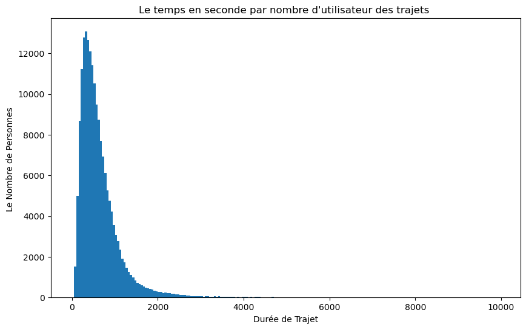

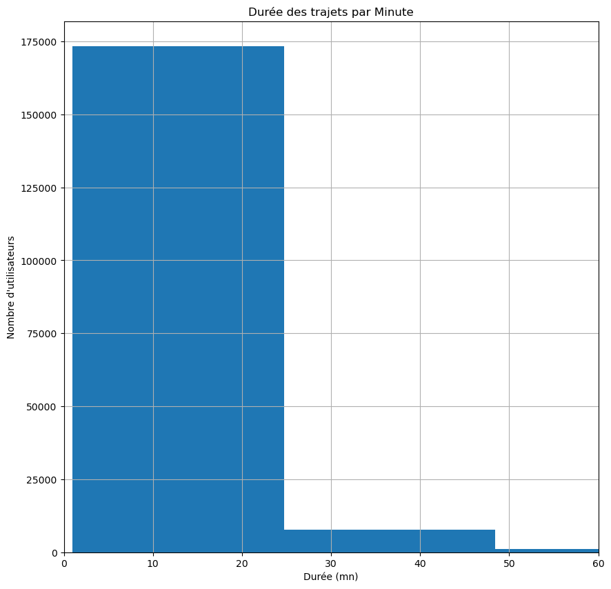

## Visualisation 2

*J'ai trouvé ces données très importantes pour ce service car il est essentiel de savoir quelles personnes utilisent le service. Pour le savoir, j'ai utilisé un "countplot" avec le type d'utilisateur comme variable. Il m'a montré qu'environ 160 000 personnes sont abonnées et moins de 20 000 personnes sont clientes.*

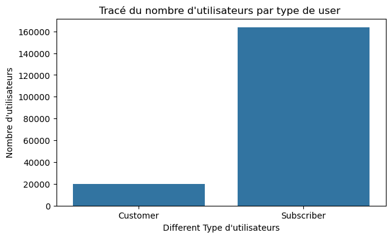

## Visualisation 3

*Pour obtenir ce resultat, j'ai utilisé une visualisation bivariée. Elle me permet de savoir quelle est la relation entre le sexe du membre et le type d'utilisateur. De cela nous pouvons deduire que pour chaque sexe de membre, il y a plus d'homme que de femme.*

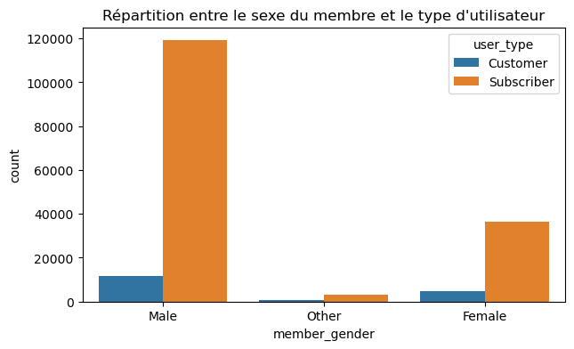